# Final Project

Vivian Kong

6/28/2019

In my final project, I am trying to build a recommender system for the good books. I only took the books csv file and ratings csv file for this project. There are 10000 books and 53424 users in the file.

The first obstacle I encountered is the file is really large. The rating csv file itself is about 69MB. This is the first time I dealt with a relatively big file. When I read csv file in R, it takes a very long time and also not loading. So, to make R running in a time fashion, I only loaded first 10,000 rows in “rating.csv”. In this case, it efficiently reduced the running time.

```r
library(recommenderlab)
library(dplyr)
library(reshape2)
library(ggplot2)

books <- read.csv("/Users/xiaomengkong/Desktop/SPS/Data612/Final Project/books.csv")
ratings <- read.csv("/Users/xiaomengkong/Desktop/SPS/Data612/Final Project/ratings.csv",nrows = 10000)

books <- data.frame(books)
ratings <- data.frame(ratings)
```

Part 1. Preparing data for “recommenderlab” and “sparklyr”

For “sparklyr”, I combined the books.csv and ratings.csv into 1 data frame by use the same “book_id. The reason why I am choosing data frame because later I would like to use Sparklyr to run ALS algorithm to do the prediction. After I combined them, I chose the columns that I need for the rating matrix or data frame. So I chose the columns of”book_id“,”authors“,”title“,”user_id“, and”rating" for my new dataframe. The reason why I keep these columns because when I do the prediction by using Sparklyr, I would like to see which book the system recommend instead of just the book-id which I did not know which book the system recommend. I called the new data frame is “NewRating” which I will use it later.

```r
books_new <- books %>% select(1,8,11)

NewRatings <- merge(books_new,ratings,by ="book_id")

head(NewRatings)
```

```
##   book_id                     authors
## 1       2 J.K. Rowling, Mary GrandPré
## 2       2 J.K. Rowling, Mary GrandPré
## 3       2 J.K. Rowling, Mary GrandPré
## 4       2 J.K. Rowling, Mary GrandPré
## 5       2 J.K. Rowling, Mary GrandPré
## 6       2 J.K. Rowling, Mary GrandPré
##                                                      title user_id rating
## 1 Harry Potter and the Sorcerer's Stone (Harry Potter, #1)      94      2
## 2 Harry Potter and the Sorcerer's Stone (Harry Potter, #1)      83      4
## 3 Harry Potter and the Sorcerer's Stone (Harry Potter, #1)     135      2
## 4 Harry Potter and the Sorcerer's Stone (Harry Potter, #1)      61      4
## 5 Harry Potter and the Sorcerer's Stone (Harry Potter, #1)     447      4
## 6 Harry Potter and the Sorcerer's Stone (Harry Potter, #1)     177      3
```

Now I am gonna prepare the wide form for my ratings matrix for “recommenderlab”. In here, I just use the ratings.csv with first 10000 rows since in this case, I don’t really need to know the book name for the prediction. In order to use the package of “recommenderlab”, I have to convert the matrix into “realRatingMatrix”.

```r
# Change ratings into wide form

head(ratings)
```

```
##   user_id book_id rating
## 1       1     258      5
## 2       2    4081      4
## 3       2     260      5
## 4       2    9296      5
## 5       2    2318      3
## 6       2      26      4
```

```r
ratings$book_id <- as.numeric(ratings$book_id)
ratings$user_id <- as.numeric(ratings$user_id)

ratings_wide <- reshape(ratings, idvar="user_id",timevar = "book_id", direction = "wide") %>% arrange(user_id)

colnames(ratings_wide)[colnames(ratings_wide)=="user_id"] <-"rating.user"
names(ratings_wide) <- substring(names(ratings_wide),8)

ratings_wide_2 <- ratings_wide[,-1]
rownames(ratings_wide_2) <- ratings_wide[,1]





head(ratings_wide_2[,1:5])
```

```
##   258 4081 260 9296 2318
## 1   5   NA  NA   NA   NA
## 2  NA    4   5    5    3
## 4  NA   NA  NA   NA   NA
## 6  NA   NA  NA   NA   NA
## 8  NA   NA  NA   NA   NA
## 9  NA   NA  NA   NA   NA
```

```r
ratings_matrix_wide <- as.matrix(ratings_wide_2)
head(ratings_matrix_wide[,1:5])
```

```
##   258 4081 260 9296 2318
## 1   5   NA  NA   NA   NA
## 2  NA    4   5    5    3
## 4  NA   NA  NA   NA   NA
## 6  NA   NA  NA   NA   NA
## 8  NA   NA  NA   NA   NA
## 9  NA   NA  NA   NA   NA
```

```r
ratings_matrix_wide[is.na(ratings_matrix_wide)] <- 0
ratings_matrix <- as(ratings_matrix_wide, "realRatingMatrix")
head(ratings_matrix)
```

```
## 1 x 2510 rating matrix of class 'realRatingMatrix' with 2510 ratings.
```

Part 2. Split the data into training and testing set. I set 70% of data values into training set, and the rest 30% into testing set. Here, I also set that any rating is above 3 which are good ratings, and below 3 is bad ratings.

```r
percentage_training <- 0.7
items_to_keep <- 100
# above 3 is good ratings, below 3 is bad ratings.
rating_threshold <- 3
# times to run the evaluation
n_eval <- 1
evaluation_set <- evaluationScheme(data=ratings_matrix,method = "split", train = percentage_training, given = items_to_keep, goodRating = rating_threshold, k = n_eval)
evaluation_set
```

```
## Evaluation scheme with 100 items given
## Method: 'split' with 1 run(s).
## Training set proportion: 0.700
## Good ratings: >=3.000000
## Data set: 255 x 2510 rating matrix of class 'realRatingMatrix' with 640050 ratings.
```

```r
getData(evaluation_set,"train")
```

```
## 178 x 2510 rating matrix of class 'realRatingMatrix' with 446780 ratings.
```

```r
nrow(getData(evaluation_set,"train")) / nrow(ratings_matrix)
```

```
## [1] 0.6980392
```

```r
# it is about 70% for our training set.
nrow(getData(evaluation_set,"known")) / nrow(ratings_matrix)
```

```
## [1] 0.3019608
```

```r
# k-fold is the most accurate approach.
n_fold <- 5
evaluation_ratingSet <- evaluationScheme(data = ratings_matrix, method = "cross-validation", k = n_fold, given = items_to_keep,goodRating = rating_threshold)
evaluation_ratingSet
```

```
## Evaluation scheme with 100 items given
## Method: 'cross-validation' with 5 run(s).
## Good ratings: >=3.000000
## Data set: 255 x 2510 rating matrix of class 'realRatingMatrix' with 640050 ratings.
```

```r
# Item-based-collaborative filtering, default parameter is "Null", "IBCF recommend new items and predict their ratings."

model_to_evaluate <- "IBCF"
model_parameters <- NULL
eval_recommender <- Recommender(data=getData(evaluation_set,"train"),method = model_to_evaluate, parameter= model_parameters)
items_to_recommend <- 5

eval_prediction <- predict(object = eval_recommender, newdata = getData(evaluation_set,"known"),n=items_to_recommend,type="ratings")
head(eval_prediction)
```

```
## 1 x 2510 rating matrix of class 'realRatingMatrix' with 1656 ratings.
```

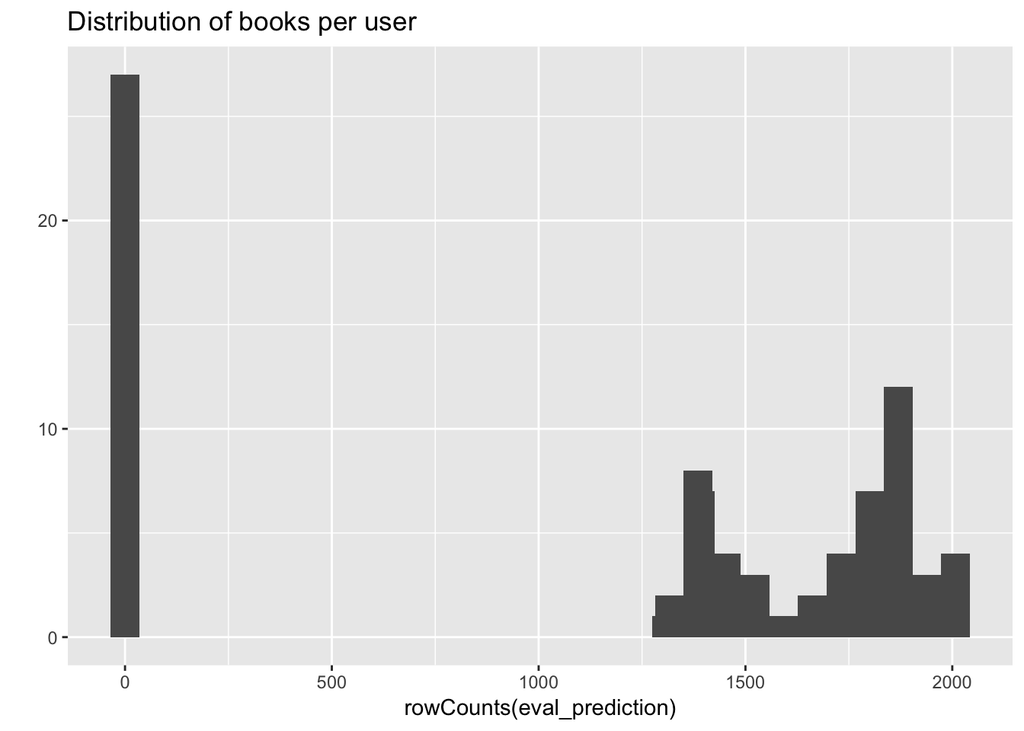

```r
qplot(rowCounts(eval_prediction)) +
  geom_histogram(binwidth = 30) +
  ggtitle("Distribution of books per user")
```

```r
eval_accuracy <- calcPredictionAccuracy( x = eval_prediction, data = getData(evaluation_set, "unknown"),byUser = TRUE)
head(eval_accuracy)
```

```
##         RMSE       MSE        MAE
## 2  0.5240051 0.2745813 0.07305819
## 10 0.7083334 0.5017362 0.12094694
## 15 0.8407079 0.7067898 0.18525537
## 28 0.6966476 0.4853179 0.11321166
## 32 0.7039326 0.4955211 0.13475733
## 36       NaN       NaN        NaN
```

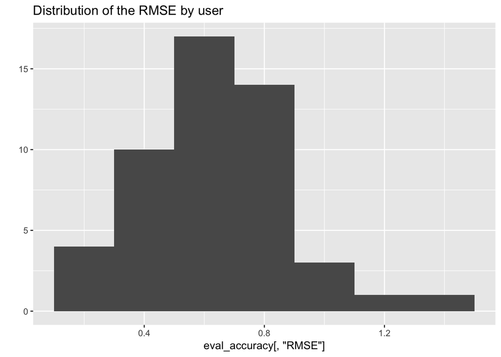

```r
qplot(eval_accuracy[,"RMSE"])+
  geom_histogram(binwidth = 0.2)+
  ggtitle("Distribution of the RMSE by user")
```

The RMSE by user from the distribution is about 0.6 which is a relatively small RMSE. I’ll consider it a pretty good prediction.

```r
results <- evaluate(x = evaluation_set,method = model_to_evaluate, n = seq(10,50,10))
```

```
## IBCF run fold/sample [model time/prediction time]
##   1  [36.732sec/0.132sec]
```

```r
head(getConfusionMatrix(results)[[1]])
```

```
##           TP        FP       FN       TN  precision     recall        TPR
## 10 0.7272727  5.766234 31.81818 2371.688 0.11200000 0.02236695 0.02236695
## 20 1.2337662 11.753247 31.31169 2365.701 0.09500000 0.03411665 0.03411665
## 30 1.5714286 17.909091 30.97403 2359.545 0.08066667 0.04322779 0.04322779
## 40 1.9610390 24.012987 30.58442 2353.442 0.07550000 0.05196597 0.05196597
## 50 2.3506494 30.116883 30.19481 2347.338 0.07240000 0.06086717 0.06086717
##            FPR
## 10 0.002436857
## 20 0.004966320
## 30 0.007567455
## 40 0.010145905
## 50 0.012724186
```

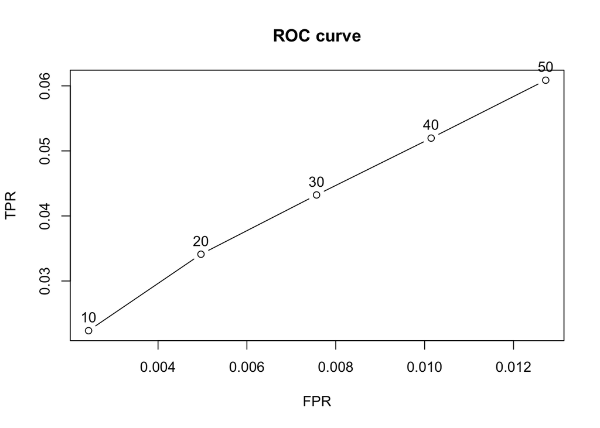

```r
plot(results, annotate = TRUE, main = "ROC curve")
```

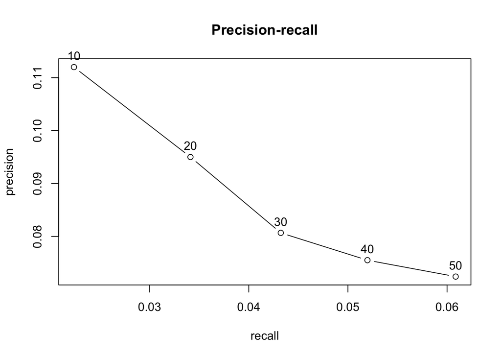

```r
plot(results,"prec/rec", annotate = TRUE, main="Precision-recall")
```

```r
models_to_evaluate <- list(
  IBCF_cos = list(name = "IBCF", param = list(method = "cosine")),
  IBCF_cor = list(name = "IBCF", param= list (method = "pearson")),
  UBCF_cos = list(name = "UBCF", param = list(method = "cosine")),
  UBCF_cor = list(name = "UBCF", param = list(method = "pearson")),
  random=list(name="RANDOM", param =NULL)
)
n_recommendations <- c (1,5, seq(10,50,10))
list_results <- evaluate(x = evaluation_set, method = models_to_evaluate, n = n_recommendations)
```

```
## IBCF run fold/sample [model time/prediction time]
##   1  [36.567sec/0.144sec]
## IBCF run fold/sample [model time/prediction time]
##   1  [39.7sec/0.131sec]
## UBCF run fold/sample [model time/prediction time]
##   1  [0.029sec/0.332sec]
## UBCF run fold/sample [model time/prediction time]
##   1  [0.029sec/0.366sec]
## RANDOM run fold/sample [model time/prediction time]
##   1  [0.004sec/0.178sec]
```

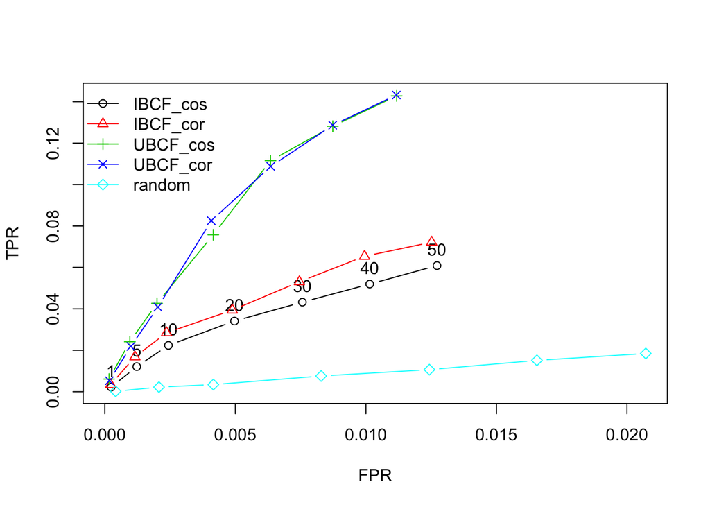

```r
plot(list_results,annotate = 1, legend = "topleft",main="ROC Curve")
```

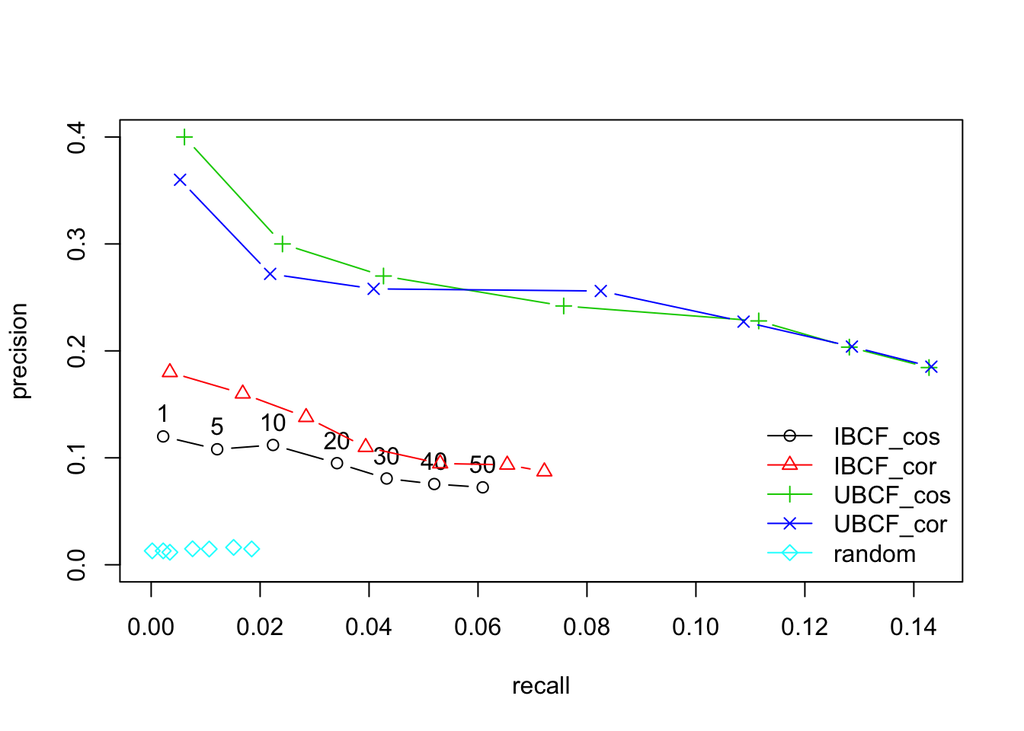

```r
plot(list_results,"prec/rec", annotate = 1, legend = "bottomright", main = "Precision-recall")
```

The good performance index is the area under the AUC curve. In our graph, the highest is UBCF with cosine distance, so it is the best-perfoming technique that we can use. For the Precision-recall graph, UBCF with cosine distance is still the top model.

```r
library(sparklyr)

sc <- spark_connect(master = "local")
sp_books <- sdf_copy_to(sc,NewRatings,"spbooks",overwrite = TRUE)
partitions <- sp_books %>% sdf_random_split(training = 0.7, test = 0.3)
sp_books_training <- partitions$training
sp_books_test <- partitions$test
head(sp_books_training)
```

```
## # Source: spark<?> [?? x 5]
##   book_id authors            title                           user_id rating
##     <int> <chr>              <chr>                             <int>  <int>
## 1       2 J.K. Rowling, Mar… Harry Potter and the Sorcerer'…      15      4
## 2       2 J.K. Rowling, Mar… Harry Potter and the Sorcerer'…      24      3
## 3       2 J.K. Rowling, Mar… Harry Potter and the Sorcerer'…      29      5
## 4       2 J.K. Rowling, Mar… Harry Potter and the Sorcerer'…      31      3
## 5       2 J.K. Rowling, Mar… Harry Potter and the Sorcerer'…      38      4
## 6       2 J.K. Rowling, Mar… Harry Potter and the Sorcerer'…      40      5
```

```r
model<- ml_als(sp_books_training,rating_col = "rating",user_col = "user_id", item_col = "book_id",rank = 10)
predictions <- ml_predict(model, sp_books_test)

predictions <- data.frame(predictions)
predictions$difference <- (predictions$rating - predictions$prediction)
predictions$difference_square <- (predictions$difference)^2

head(predictions)
```

```
##   book_id                                 authors title user_id rating
## 1      13 George Orwell, Erich Fromm, Celâl Üster  1984      25      4
## 2      13 George Orwell, Erich Fromm, Celâl Üster  1984     263      5
## 3      13 George Orwell, Erich Fromm, Celâl Üster  1984     413      5
## 4      13 George Orwell, Erich Fromm, Celâl Üster  1984       9      5
## 5      13 George Orwell, Erich Fromm, Celâl Üster  1984      15      4
## 6      13 George Orwell, Erich Fromm, Celâl Üster  1984      40      4
##   prediction  difference difference_square
## 1   4.616210 -0.61621046       0.379715332
## 2   4.452583  0.54741669       0.299665029
## 3   3.708073  1.29192734       1.669076246
## 4   3.936816  1.06318402       1.130360267
## 5   4.821208 -0.82120800       0.674382580
## 6   3.922015  0.07798505       0.006081668
```

```r
sqrt(mean(predictions$difference_square,na.rm = TRUE))
```

```
## [1] 1.265403
```

Conclusion: Throughout this summer semester, I think this is a very interesting topic to learn since we live with it all the time whether we like the recommender system or not. Overall, I think the recommender system is convinient for our lives although the developer has to aware of the ethical issues may get involved. I think I learn a lot from this semester, especially when it uses linear algebra to do the recommendations. I find it fancinating. Summer class is pretty short but I would like to explore more about this topic after the class.